# Contractor ties at the World Bank

## Who works for whom?

Put yourself in the shoes of a loan recipient from the World Bank: you have the capital to do what you wanted to do, and now you need to figure out who will actually do the work. This choice should probably be a pragmatic, practical one. The work should be done by the person who will do it best. This pragmatism doesn’t always drive the decisions of project managers, however. There could be a firm with an established relationship with the borrower country, at home or abroad, a relationship built on reputation, loyalty, or, worse, graft. The country I grew up in seems to thrive on the latter to this day.

Without alleging any embezzlement in contractor relationships, let’s examine some broader questions. For instance, for each borrower country, what portion of the contracts are performed by domestic firms versus foreign ones? One obvious limitation here: a firm might be registered in India, but it does not necessarily make it an Indian business. Unfortunately, this is as far as we can go with the public information available, so we’ll have to settle here and beware of the bias.

```r
#We will recycle a data frame we created earlier - country.data

country.prop <- country.data %>% group_by(Borrower.Country, Supplier.Country) %>% summarise(dollar.sum = sum(amount), contract.sum = sum(contract.count)) %>% mutate(dollar.proportion = (dollar.sum/sum(dollar.sum) * 100), contract.proportion = (contract.sum/sum(contract.sum))*100) %>% filter(Borrower.Country == Supplier.Country)

proportions.map <- gvisGeoChart(country.prop, locationvar = 'Borrower.Country', colorvar = 'dollar.proportion', sizevar = 'contract.proportion', options=list(colorAxis = "{values:[0, 100], colors:['white', 'red']}", width=860, height=600))
```

```r
print(proportions.map, 'chart')
```

By the looks of it, countries prefer keeping contracts and contract money at home. In some acute cases, such as Brazil or Argentina, some 90%+ of contract volume is reserved for domestic firms. Notice how that seems to hold true in Latin America in general. Part of this probably has to do with the types of projects that are happening in each region: Latin America, as I learned in my thesis work, seems to rely on smaller scale health, education, and governance efforts, as well as medium-size infrastructure projects. If you are going to build a school, chances are you’ll buy your cement somewhere nearby.

Now look at Central Asia. In Turkmenistan, Kazakhstan, and Uzbekistan, there seem to be far more outsiders working on development projects compared to the average globally. Some countries in Central Africa, too, exhibit this same behavior. Take Algeria, for instance, where only 33% of contract work is awarded to domestic firms. I wonder if this has anything to do with the availability of the services demanded in those countries. I’d hate to generalize about the level of economic development in those places, but if there isn’t a firm that knows how to lay internet cable around you’ll probably have to go look elsewhere, potentially even abroad.

In general, I think it would be fair to conclude the most borrower countries are self sufficient and can mobilize the resources needed to complete the projects financed by the World Bank. To varying degree, they fill the knowledge or resource vacuum by contracting outsiders; we will look at this behavior next.

## Help from the outside

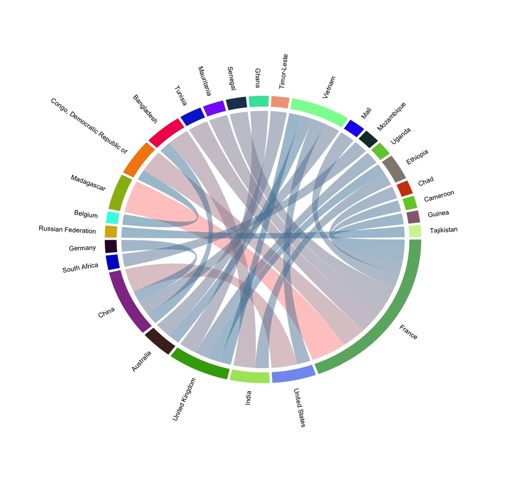

```r
#create a chord diagram sample
#first, let's remove all the "self-supplying" we looked at above
country.data$type <- mapply(identical, country.data$Borrower.Country, country.data$Supplier.Country)
country.data <- country.data %>% filter(type == FALSE) %>% select(1:3) %>% ungroup() %>% arrange(desc(amount)) %>% top_n(25) %>% select(Supplier.Country, Borrower.Country, amount)

#now let's define the attributes of the chord graph - the colors of the links namely
col_fun <- colorRamp2(range(country.data$amount), c("#4281a4", "#fe938c"))

chord.diagram <- chordDiagram(country.data, col = col_fun, annotationTrack = "grid", preAllocateTracks=list(track.height = 0.3))

circos.trackPlotRegion(track.index=1, panel.fun=function(x,y) {
  xlim = get.cell.meta.data("xlim")
  ylim = get.cell.meta.data("ylim")
  sector.name=get.cell.meta.data("sector.index")
  circos.text(mean(xlim), ylim[1], sector.name,facing="clockwise",
              niceFacing=TRUE,adj=c(0,0.5))},bg.border=NA)
```